# DATA PREPROCESSING AND EDA

```python
import pandas as pd
import numpy as np                     # For mathematical calculations
import seaborn as sns                  # For data visualization
import matplotlib.pyplot as plt        # For plotting graphs
%matplotlib inline
import warnings
```

```python
train=pd.read_csv("Disease Prediction Training(1).csv")
test=pd.read_csv("Disease Prediction Testing(1).csv")
```

making a copy of train and test data so that even if we have to make any changes in these datasets we would not lose the original datase

```python
train_original=train.copy()
test_original=test.copy()
```

```python
#combining the training and testing datasets
data = pd.concat([train, test.drop(['ID'], axis=1)])
```

```python
#checking for missing values in the training data
train.isnull().sum()
```

```
Age                    0
Gender                 0
Height                 0
Weight                 0
High Blood Pressure    0
Low Blood Pressure     0
Cholesterol            0
Glucose                0
Smoke                  0
Alcohol                0
Exercise               0
Disease                0
dtype: int64
```

```python
#Summary statistics of our training data
train.describe()
```

|  | Age | Height | Weight | High Blood Pressure | Low Blood Pressure | Smoke | Alcohol | Exercise | Disease |
| --- | --- | --- | --- | --- | --- | --- | --- | --- | --- |
| count | 49000.000000 | 49000.000000 | 49000.000000 | 49000.000000 | 49000.000000 | 49000.000000 | 49000.000000 | 49000.000000 | 49000.000000 |
| mean | 52.853306 | 164.366878 | 74.190527 | 128.698939 | 96.917367 | 0.088265 | 0.054245 | 0.803204 | 0.499959 |
| std | 6.763065 | 8.216637 | 14.329934 | 147.624582 | 200.368069 | 0.283683 | 0.226503 | 0.397581 | 0.500005 |
| min | 29.000000 | 55.000000 | 10.000000 | -150.000000 | 0.000000 | 0.000000 | 0.000000 | 0.000000 | 0.000000 |
| 25% | 48.000000 | 159.000000 | 65.000000 | 120.000000 | 80.000000 | 0.000000 | 0.000000 | 1.000000 | 0.000000 |
| 50% | 53.000000 | 165.000000 | 72.000000 | 120.000000 | 80.000000 | 0.000000 | 0.000000 | 1.000000 | 0.000000 |
| 75% | 58.000000 | 170.000000 | 82.000000 | 140.000000 | 90.000000 | 0.000000 | 0.000000 | 1.000000 | 1.000000 |
| max | 64.000000 | 207.000000 | 200.000000 | 14020.000000 | 11000.000000 | 1.000000 | 1.000000 | 1.000000 | 1.000000 |

```python
# printing the maximun values in the dataset to see if there are any unusal values
maxValuesObj = train.max()

print('Maximum value in each column : ')
print(maxValuesObj)
```

```
Maximum value in each column :
Age                          64
Gender                     male
Height                      207
Weight                      200
High Blood Pressure       14020
Low Blood Pressure        11000
Cholesterol            too high
Glucose                too high
Smoke                         1
Alcohol                       1
Exercise                      1
Disease                       1
dtype: object
```

lets see if our data set is balanced or imbalaced. If the data is imbalanced we may have use some oversampling or undersampling methods on data.

```python
train['Disease'].value_counts(normalize=True)
```

```
0    0.500041
1    0.499959
Name: Disease, dtype: float64
```

we see that the data is almost if not perfectly balaced with 50-50 distribution of our target variable and hence we may avoid any oversampling or undersampling methods.

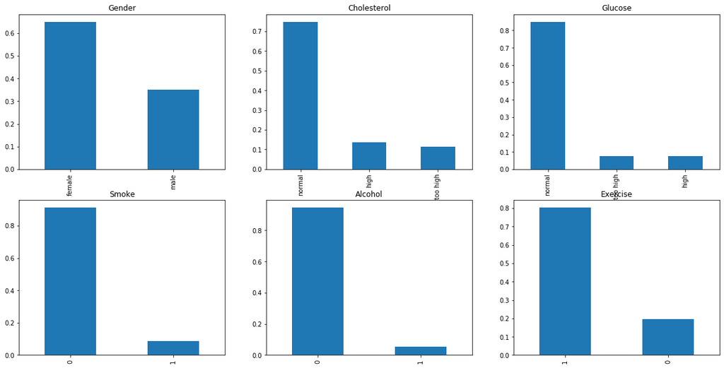

```python
fig = plt.figure(figsize=(14,12))

#  subplot #1
fig.add_subplot(231)
plt.title('Gender', fontsize=14)
train['Gender'].value_counts(normalize=True).plot.bar(figsize=(20,10), title= 'Gender')

#  subplot #2
fig.add_subplot(2,3,2)
train['Cholesterol'].value_counts(normalize=True).plot.bar(title= 'Cholesterol')

#  subplot #3
fig.add_subplot(233)
train['Glucose'].value_counts(normalize=True).plot.bar(title= 'Glucose')

fig.add_subplot(234)
train['Smoke'].value_counts(normalize=True).plot.bar(title= 'Smoke')

fig.add_subplot(235)
train['Alcohol'].value_counts(normalize=True).plot.bar(title= 'Alcohol')

fig.add_subplot(236)
train['Exercise'].value_counts(normalize=True).plot.bar(title= 'Exercise')



plt.show()
```

It can be inferred from the above bar plots that:

Around 75% of the patients in the dataset have normal cholestral.

Around 85% patients in the dataset have normal glucose.

Around 10 % patients in the dataset smoke.

Around 5% patients in the dataset drink alcohol.

Around 80% patients in the dataset exercise.

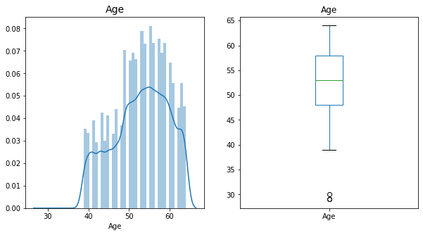

```python
fig = plt.figure(figsize=(10,5))

#  subplot #1
fig.add_subplot(121)
plt.title('Age', fontsize=14)
sns.distplot(train['Age'])

#  subplot #2
fig.add_subplot(1,2,2)
train['Age'].plot.box(title= 'Age')


plt.show()
```

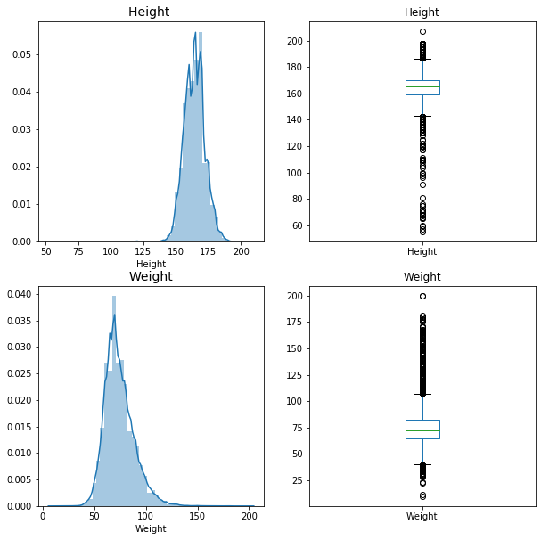

```python
fig = plt.figure(figsize=(10,10))

#  subplot #1
fig.add_subplot(221)
plt.title('Height ', fontsize=14)
sns.distplot(train["Height"])

#  subplot #2
fig.add_subplot(2,2,2)
train['Height'].plot.box(title= 'Height')


#  subplot #1
fig.add_subplot(223)
plt.title('Weight', fontsize=14)
sns.distplot(train['Weight'])

#  subplot #2
fig.add_subplot(2,2,4)
train['Weight'].plot.box(title= 'Weight')


plt.show()
```

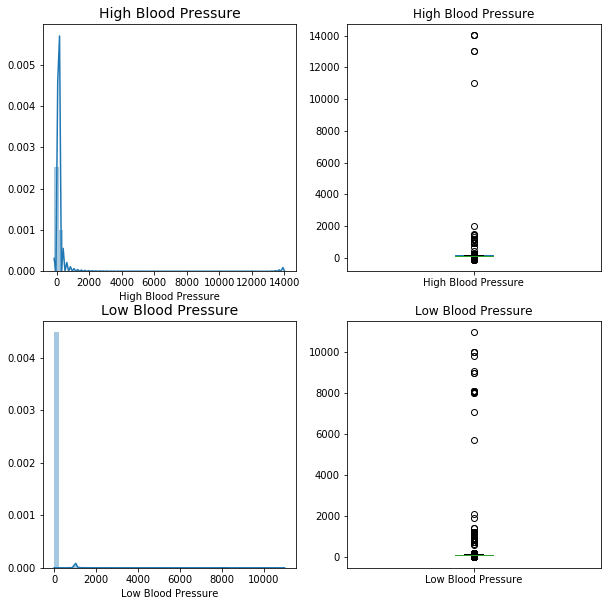

```python
fig = plt.figure(figsize=(10,10))

#  subplot #1
fig.add_subplot(221)
plt.title('High Blood Pressure', fontsize=14)
sns.distplot(train['High Blood Pressure'])

#  subplot #2
fig.add_subplot(2,2,2)
train['High Blood Pressure'].plot.box(title= 'High Blood Pressure')



#  subplot #1
fig.add_subplot(223)
plt.title('Low Blood Pressure', fontsize=14)
sns.distplot(train['Low Blood Pressure'])

#  subplot #2
fig.add_subplot(224)
train['Low Blood Pressure'].plot.box(title= 'Low Blood Pressure')

plt.show()
```

The variables Hight bllod presuure and low blood pressure have high skeness in the distribution and also the outliers have no meaning in this case. A person canot have values of low blood pressure and high blood poresuure in thousands and hence these two variables have lot outliers which are errors and hence we have to use some techniques to treate outliers from both of them.

```python
arr = ["Height","Weight", "High Blood Pressure", "Low Blood Pressure"]

for i in arr:
    IQR = data[i].quantile(0.75) - data[i].quantile(0.25)
    upper_bound = data[i].quantile(0.75) + (IQR * 1.5)
    lower_bound = data[i].quantile(0.25) - (IQR * 1.5)
    max_val = data[i].max()
    min_val = data[i].min()
    median_val = np.median(data[i])
    print("upper bound of :"+i , upper_bound)
    print("lower bound of :"+i,lower_bound )
    print("maximum value in dataset of :"+i, max_val)
    print("median value in dataset of :"+i, median_val)
```

```
upper bound of :Height 186.5
lower bound of :Height 142.5
maximum value in dataset of :Height 250
median value in dataset of :Height 165.0
upper bound of :Weight 107.5
lower bound of :Weight 39.5
maximum value in dataset of :Weight 200.0
median value in dataset of :Weight 72.0
upper bound of :High Blood Pressure 170.0
lower bound of :High Blood Pressure 90.0
maximum value in dataset of :High Blood Pressure 16020
median value in dataset of :High Blood Pressure 120.0
upper bound of :Low Blood Pressure 105.0
lower bound of :Low Blood Pressure 65.0
maximum value in dataset of :Low Blood Pressure 11000
median value in dataset of :Low Blood Pressure 80.0
```

Therefore for both High blood pressure and low pressure i will be treating my outliers by imputing any values more than the upper bound and less than the lowerbound by median values of their respective columns

**Therefore for both High blood pressure and low pressure i will be treating my outliers by imputing any values more than the upper bound and less than the lowerbound by median values of their respective columns**

```python
data.loc[data['High Blood Pressure'] > 170, 'High Blood Pressure'] = 120
data.loc[data['High Blood Pressure'] < 90, 'High Blood Pressure'] = 120

data.loc[data['Low Blood Pressure'] > 105, 'Low Blood Pressure'] = 80
data.loc[data['Low Blood Pressure'] < 65, 'Low Blood Pressure'] = 80
```

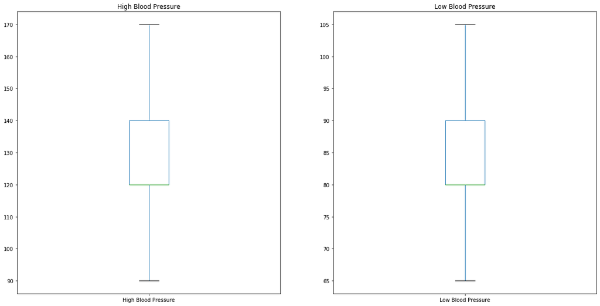

```python
fig = plt.figure(figsize=(20,10))


#  subplot #2
fig.add_subplot(1,2,1)
data['High Blood Pressure'].plot.box(title= 'High Blood Pressure')


#  subplot #2
fig.add_subplot(1,2,2)
data['Low Blood Pressure'].plot.box(title= 'Low Blood Pressure')

plt.show()
```

```python
Hmeter = data.Height/100
Hmeter = pd.DataFrame(Hmeter)
train_data = pd.concat([data, Hmeter], axis=1, sort=False)
#train_data.rename(columns ={2: "h_in_cm"}, inplace =True)
```

```python
data.head()
```

|  | Age | Gender | Height | Weight | High Blood Pressure | Low Blood Pressure | Cholesterol | Glucose | Smoke | Alcohol | Exercise | Disease |
| --- | --- | --- | --- | --- | --- | --- | --- | --- | --- | --- | --- | --- |
| 0 | 59 | female | 167 | 88.0 | 130 | 68 | normal | normal | 0 | 0 | 1 | 0.0 |
| 1 | 64 | female | 150 | 71.0 | 140 | 100 | normal | normal | 0 | 0 | 0 | 1.0 |
| 2 | 41 | female | 166 | 83.0 | 100 | 70 | normal | normal | 0 | 1 | 1 | 0.0 |
| 3 | 50 | male | 172 | 110.0 | 130 | 80 | normal | normal | 1 | 0 | 1 | 0.0 |
| 4 | 39 | female | 162 | 61.0 | 110 | 80 | high | high | 0 | 0 | 1 | 0.0 |

```python
train_data.columns = ['Age', 'Gender', 'HinCM', 'Weight', 'High Blood Pressure',
        'Low Blood Pressure', 'Cholesterol', 'Glucose', 'Smoke', 'Alcohol',
        'Exercise', 'Disease', 'Height']
```

```python
train_data.head()
```

|  | Age | Gender | HinCM | Weight | High Blood Pressure | Low Blood Pressure | Cholesterol | Glucose | Smoke | Alcohol | Exercise | Disease | Height |
| --- | --- | --- | --- | --- | --- | --- | --- | --- | --- | --- | --- | --- | --- |
| 0 | 59 | female | 167 | 88.0 | 130 | 68 | normal | normal | 0 | 0 | 1 | 0.0 | 1.67 |
| 1 | 64 | female | 150 | 71.0 | 140 | 100 | normal | normal | 0 | 0 | 0 | 1.0 | 1.50 |
| 2 | 41 | female | 166 | 83.0 | 100 | 70 | normal | normal | 0 | 1 | 1 | 0.0 | 1.66 |
| 3 | 50 | male | 172 | 110.0 | 130 | 80 | normal | normal | 1 | 0 | 1 | 0.0 | 1.72 |
| 4 | 39 | female | 162 | 61.0 | 110 | 80 | high | high | 0 | 0 | 1 | 0.0 | 1.62 |

```python
BMI = (train_data.Weight)/(train_data.Height)**2
BMI = pd.DataFrame(BMI)
train_data = pd.concat([train_data, BMI], axis=1, sort=False)
#new_df.drop(['Cholesterol', 'Glucose'], axis=1)
train_data.head()
```

|  | Age | Gender | HinCM | Weight | High Blood Pressure | Low Blood Pressure | Cholesterol | Glucose | Smoke | Alcohol | Exercise | Disease | Height | 0 |
| --- | --- | --- | --- | --- | --- | --- | --- | --- | --- | --- | --- | --- | --- | --- |
| 0 | 59 | female | 167 | 88.0 | 130 | 68 | normal | normal | 0 | 0 | 1 | 0.0 | 1.67 | 31.553659 |
| 1 | 64 | female | 150 | 71.0 | 140 | 100 | normal | normal | 0 | 0 | 0 | 1.0 | 1.50 | 31.555556 |
| 2 | 41 | female | 166 | 83.0 | 100 | 70 | normal | normal | 0 | 1 | 1 | 0.0 | 1.66 | 30.120482 |
| 3 | 50 | male | 172 | 110.0 | 130 | 80 | normal | normal | 1 | 0 | 1 | 0.0 | 1.72 | 37.182261 |
| 4 | 39 | female | 162 | 61.0 | 110 | 80 | high | high | 0 | 0 | 1 | 0.0 | 1.62 | 23.243408 |

```python
train_data.columns = ['Age', 'Gender', 'HinCM', 'Weight', 'High Blood Pressure',
        'Low Blood Pressure', 'Cholesterol', 'Glucose', 'Smoke', 'Alcohol',
        'Exercise', 'Disease', 'Height', "BMI"]
train_data.head()
```

|  | Age | Gender | HinCM | Weight | High Blood Pressure | Low Blood Pressure | Cholesterol | Glucose | Smoke | Alcohol | Exercise | Disease | Height | BMI |
| --- | --- | --- | --- | --- | --- | --- | --- | --- | --- | --- | --- | --- | --- | --- |
| 0 | 59 | female | 167 | 88.0 | 130 | 68 | normal | normal | 0 | 0 | 1 | 0.0 | 1.67 | 31.553659 |
| 1 | 64 | female | 150 | 71.0 | 140 | 100 | normal | normal | 0 | 0 | 0 | 1.0 | 1.50 | 31.555556 |
| 2 | 41 | female | 166 | 83.0 | 100 | 70 | normal | normal | 0 | 1 | 1 | 0.0 | 1.66 | 30.120482 |
| 3 | 50 | male | 172 | 110.0 | 130 | 80 | normal | normal | 1 | 0 | 1 | 0.0 | 1.72 | 37.182261 |
| 4 | 39 | female | 162 | 61.0 | 110 | 80 | high | high | 0 | 0 | 1 | 0.0 | 1.62 | 23.243408 |

```python
HBP_LBP = (train_data["High Blood Pressure"]) + (train_data["Low Blood Pressure"])
HBP_LBP = pd.DataFrame(HBP_LBP)
train_data = pd.concat([train_data, HBP_LBP], axis=1, sort=False)
#new_df.drop(['Cholesterol', 'Glucose'], axis=1)
train_data.head()
```

|  | Age | Gender | HinCM | Weight | High Blood Pressure | Low Blood Pressure | Cholesterol | Glucose | Smoke | Alcohol | Exercise | Disease | Height | BMI | 0 |
| --- | --- | --- | --- | --- | --- | --- | --- | --- | --- | --- | --- | --- | --- | --- | --- |
| 0 | 59 | female | 167 | 88.0 | 130 | 68 | normal | normal | 0 | 0 | 1 | 0.0 | 1.67 | 31.553659 | 198 |
| 1 | 64 | female | 150 | 71.0 | 140 | 100 | normal | normal | 0 | 0 | 0 | 1.0 | 1.50 | 31.555556 | 240 |
| 2 | 41 | female | 166 | 83.0 | 100 | 70 | normal | normal | 0 | 1 | 1 | 0.0 | 1.66 | 30.120482 | 170 |
| 3 | 50 | male | 172 | 110.0 | 130 | 80 | normal | normal | 1 | 0 | 1 | 0.0 | 1.72 | 37.182261 | 210 |
| 4 | 39 | female | 162 | 61.0 | 110 | 80 | high | high | 0 | 0 | 1 | 0.0 | 1.62 | 23.243408 | 190 |

```python
train_data.columns = ['Age', 'Gender', 'HinCM', 'Weight', 'High Blood Pressure',
        'Low Blood Pressure', 'Cholesterol', 'Glucose', 'Smoke', 'Alcohol',
        'Exercise', 'Disease', 'Height', "BMI", "HBPLBP"]
train_data.head()
```

|  | Age | Gender | HinCM | Weight | High Blood Pressure | Low Blood Pressure | Cholesterol | Glucose | Smoke | Alcohol | Exercise | Disease | Height | BMI | HBPLBP |
| --- | --- | --- | --- | --- | --- | --- | --- | --- | --- | --- | --- | --- | --- | --- | --- |
| 0 | 59 | female | 167 | 88.0 | 130 | 68 | normal | normal | 0 | 0 | 1 | 0.0 | 1.67 | 31.553659 | 198 |
| 1 | 64 | female | 150 | 71.0 | 140 | 100 | normal | normal | 0 | 0 | 0 | 1.0 | 1.50 | 31.555556 | 240 |
| 2 | 41 | female | 166 | 83.0 | 100 | 70 | normal | normal | 0 | 1 | 1 | 0.0 | 1.66 | 30.120482 | 170 |
| 3 | 50 | male | 172 | 110.0 | 130 | 80 | normal | normal | 1 | 0 | 1 | 0.0 | 1.72 | 37.182261 | 210 |
| 4 | 39 | female | 162 | 61.0 | 110 | 80 | high | high | 0 | 0 | 1 | 0.0 | 1.62 | 23.243408 | 190 |

```python
new_df = train_data.drop('Height', axis=1)
```

```python
new_df.head()
```

|  | Age | Gender | HinCM | Weight | High Blood Pressure | Low Blood Pressure | Cholesterol | Glucose | Smoke | Alcohol | Exercise | Disease | BMI | HBPLBP |
| --- | --- | --- | --- | --- | --- | --- | --- | --- | --- | --- | --- | --- | --- | --- |
| 0 | 59 | female | 167 | 88.0 | 130 | 68 | normal | normal | 0 | 0 | 1 | 0.0 | 31.553659 | 198 |
| 1 | 64 | female | 150 | 71.0 | 140 | 100 | normal | normal | 0 | 0 | 0 | 1.0 | 31.555556 | 240 |
| 2 | 41 | female | 166 | 83.0 | 100 | 70 | normal | normal | 0 | 1 | 1 | 0.0 | 30.120482 | 170 |
| 3 | 50 | male | 172 | 110.0 | 130 | 80 | normal | normal | 1 | 0 | 1 | 0.0 | 37.182261 | 210 |
| 4 | 39 | female | 162 | 61.0 | 110 | 80 | high | high | 0 | 0 | 1 | 0.0 | 23.243408 | 190 |

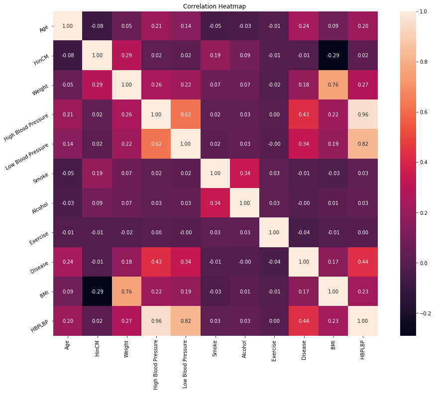

```python
correlation = new_df.corr()

plt.figure(figsize=(16,12))
plt.title('Correlation Heatmap ')
ax = sns.heatmap(correlation, square=True, annot=True, fmt='.2f', linecolor='white')
ax.set_xticklabels(ax.get_xticklabels(), rotation=90)
ax.set_yticklabels(ax.get_yticklabels(), rotation=30)
plt.show()
```

I observed that there is significant correlation between 1) High blood pressure and Low blood pressure 2) High blood pressure and Disease 3) Low Blood Pressure and Disease 4) Age and Disease 5) BMI has correlation with height and weight 6) HBPLBP has correlation with High blood pressure and Low blood pressure

```python
new_df = pd.concat([new_df, pd.get_dummies(new_df["Gender"], prefix="Gender")], axis=1)
#delete the categorical Gender column and keep the encoded columns
del new_df['Gender']
new_df.head()
```

|  | Age | HinCM | Weight | High Blood Pressure | Low Blood Pressure | Cholesterol | Glucose | Smoke | Alcohol | Exercise | Disease | BMI | HBPLBP | Gender_female | Gender_male |
| --- | --- | --- | --- | --- | --- | --- | --- | --- | --- | --- | --- | --- | --- | --- | --- |
| 0 | 59 | 167 | 88.0 | 130 | 68 | normal | normal | 0 | 0 | 1 | 0.0 | 31.553659 | 198 | 1 | 0 |
| 1 | 64 | 150 | 71.0 | 140 | 100 | normal | normal | 0 | 0 | 0 | 1.0 | 31.555556 | 240 | 1 | 0 |
| 2 | 41 | 166 | 83.0 | 100 | 70 | normal | normal | 0 | 1 | 1 | 0.0 | 30.120482 | 170 | 1 | 0 |
| 3 | 50 | 172 | 110.0 | 130 | 80 | normal | normal | 1 | 0 | 1 | 0.0 | 37.182261 | 210 | 0 | 1 |
| 4 | 39 | 162 | 61.0 | 110 | 80 | high | high | 0 | 0 | 1 | 0.0 | 23.243408 | 190 | 1 | 0 |

```python
diagnosis_map = {'normal':0, 'high':1, 'too high':2}
new_df['Cholesterol'] = new_df['Cholesterol'].map(diagnosis_map)
new_df['Glucose'] = new_df['Glucose'].map(diagnosis_map)
new_df.head()
```

|  | Age | HinCM | Weight | High Blood Pressure | Low Blood Pressure | Cholesterol | Glucose | Smoke | Alcohol | Exercise | Disease | BMI | HBPLBP | Gender_female | Gender_male |
| --- | --- | --- | --- | --- | --- | --- | --- | --- | --- | --- | --- | --- | --- | --- | --- |
| 0 | 59 | 167 | 88.0 | 130 | 68 | 0 | 0 | 0 | 0 | 1 | 0.0 | 31.553659 | 198 | 1 | 0 |
| 1 | 64 | 150 | 71.0 | 140 | 100 | 0 | 0 | 0 | 0 | 0 | 1.0 | 31.555556 | 240 | 1 | 0 |
| 2 | 41 | 166 | 83.0 | 100 | 70 | 0 | 0 | 0 | 1 | 1 | 0.0 | 30.120482 | 170 | 1 | 0 |
| 3 | 50 | 172 | 110.0 | 130 | 80 | 0 | 0 | 1 | 0 | 1 | 0.0 | 37.182261 | 210 | 0 | 1 |
| 4 | 39 | 162 | 61.0 | 110 | 80 | 1 | 1 | 0 | 0 | 1 | 0.0 | 23.243408 | 190 | 1 | 0 |

# NAIVE BAYES IMPLEMENTATION

```python
df1 = new_df.drop(["BMI","HBPLBP"],axis=1)
df1_training = df1.head(49000)
df1_testing = df1.tail(21000)
```

```python
print (df1_training.shape)
print(df1_testing.shape)
```

```
(49000, 13)
(21000, 13)
```

```python
df1_training.head()
```

|  | Age | HinCM | Weight | High Blood Pressure | Low Blood Pressure | Cholesterol | Glucose | Smoke | Alcohol | Exercise | Disease | Gender_female | Gender_male |
| --- | --- | --- | --- | --- | --- | --- | --- | --- | --- | --- | --- | --- | --- |
| 0 | 59 | 167 | 88.0 | 130 | 68 | 0 | 0 | 0 | 0 | 1 | 0.0 | 1 | 0 |
| 1 | 64 | 150 | 71.0 | 140 | 100 | 0 | 0 | 0 | 0 | 0 | 1.0 | 1 | 0 |
| 2 | 41 | 166 | 83.0 | 100 | 70 | 0 | 0 | 0 | 1 | 1 | 0.0 | 1 | 0 |
| 3 | 50 | 172 | 110.0 | 130 | 80 | 0 | 0 | 1 | 0 | 1 | 0.0 | 0 | 1 |
| 4 | 39 | 162 | 61.0 | 110 | 80 | 1 | 1 | 0 | 0 | 1 | 0.0 | 1 | 0 |

```python
df1_testing = df1_testing.drop("Disease", axis=1)
df1_testing.head()
```

|  | Age | HinCM | Weight | High Blood Pressure | Low Blood Pressure | Cholesterol | Glucose | Smoke | Alcohol | Exercise | Gender_female | Gender_male |
| --- | --- | --- | --- | --- | --- | --- | --- | --- | --- | --- | --- | --- |
| 0 | 44 | 160 | 59.0 | 100 | 80 | 1 | 0 | 0 | 0 | 1 | 1 | 0 |
| 1 | 41 | 169 | 74.0 | 120 | 70 | 0 | 0 | 0 | 0 | 1 | 1 | 0 |
| 2 | 63 | 168 | 84.0 | 120 | 80 | 0 | 1 | 0 | 0 | 1 | 0 | 1 |
| 3 | 55 | 158 | 108.0 | 160 | 100 | 0 | 0 | 0 | 0 | 0 | 1 | 0 |
| 4 | 55 | 167 | 67.0 | 120 | 80 | 0 | 0 | 0 | 0 | 1 | 1 | 0 |

```python
import numpy as np
import matplotlib.pyplot as plt
import pandas as pd
from sklearn.model_selection import train_test_split
from sklearn.preprocessing import StandardScaler
from sklearn import metrics
from sklearn.pipeline import make_pipeline
from sklearn.model_selection import ShuffleSplit
from sklearn.model_selection import cross_val_score
import seaborn as sns
from sklearn.decomposition import PCA
from sklearn.svm import SVC
from sklearn import svm
from sklearn import model_selection
from sklearn.model_selection import GridSearchCV
from matplotlib.legend_handler import HandlerLine2D
```

```python
X = df1_training.drop("Disease", axis=1)
y = df1_training["Disease"]
X_train, X_test, y_train,y_test = train_test_split(X, y, test_size=0.3, random_state=1)
scaler = StandardScaler()
scaler.fit(X_train)
```

```
StandardScaler(copy=True, with_mean=True, with_std=True)
```

```python
X_train_std = scaler.transform(X_train)
X_test_std = scaler.transform(X_test)
```

```python
from sklearn.naive_bayes import GaussianNB, BernoulliNB, MultinomialNB
gnb = GaussianNB()
gnb.fit(X_train_std, y_train)
```

```
GaussianNB(priors=None, var_smoothing=1e-09)
```

```python
gnb_pred = gnb.predict(X_test_std)
print(f"Accuracy: {round(metrics.accuracy_score(y_test, gnb_pred)*100, 2)}%")
```

```
Accuracy: 71.39%
```

```python
df1_testing = scaler.transform(df1_testing)
```

```python
len(df1_testing)
```

```
21000
```

```python
test_data_predictions = gnb.predict(df1_testing)
GNB_predictions = pd.DataFrame(test_data_predictions)
GNB_predictions.shape
```

```
(21000, 1)
```

```python
submission_df = test_original["ID"]
submission_df = pd.concat([submission_df, GNB_predictions], axis=1, sort=False)
submission_df.shape
```

```
(21000, 2)
```

```python
submission_df.to_csv('ons_1_assign3_da.csv', index=False)
```

```python
import sklearn.metrics
predictions= gnb.predict(X_test_std)
confusion = sklearn.metrics.confusion_matrix(y_test,predictions)

accuracy = sklearn.metrics.accuracy_score(y_test, predictions)
sensitivity = confusion[1][1]/float(confusion[1:].sum())
specificity = confusion[0][0]/float(confusion[:,0].sum())
print ("The accuracy is {0:.3f}".format(accuracy))
print ("The sensitivity is {0:.3f}".format(sensitivity))
print ("The specificity is {0:.3f}".format(specificity))
```

```
The accuracy is 0.714
The sensitivity is 0.621
The specificity is 0.684
```

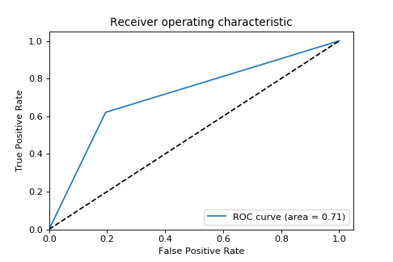

```python
# plotting roc curve with AUC
from sklearn.metrics import roc_curve, auc
false_positive_rate, true_positive_rate, thresholds = roc_curve(y_test,predictions)
roc_auc = auc(false_positive_rate, true_positive_rate)

# Plot of a ROC curve for a classification tree
%matplotlib notebook
plt.figure()
plt.plot(false_positive_rate, true_positive_rate, label='ROC curve (area = %0.2f)' % roc_auc)
plt.plot([0, 1], [0, 1], 'k--')
plt.xlim([0.0, 1.05])
plt.ylim([0.0, 1.05])
plt.xlabel('False Positive Rate')
plt.ylabel('True Positive Rate')
plt.title('Receiver operating characteristic')
plt.legend(loc="lower right")
plt.show()
```

# SVM

```python
lin_clf = svm.LinearSVC()
lin_clf
bs = model_selection.ShuffleSplit(n_splits=5,test_size=0.3,random_state=0)
param_grid = {'C':[0.25,0.5,1],'penalty':['l2']}

gridbs = GridSearchCV(lin_clf,param_grid,cv=bs)
gridbs.fit(X_train_std, y_train)
```

```
GridSearchCV(cv=ShuffleSplit(n_splits=5, random_state=0, test_size=0.3, train_size=None),
             error_score=nan,
             estimator=LinearSVC(C=1.0, class_weight=None, dual=True,
                                 fit_intercept=True, intercept_scaling=1,
                                 loss='squared_hinge', max_iter=1000,
                                 multi_class='ovr', penalty='l2',
                                 random_state=None, tol=0.0001, verbose=0),
             iid='deprecated', n_jobs=None,
             param_grid={'C': [0.25, 0.5, 1], 'penalty': ['l2']},
             pre_dispatch='2*n_jobs', refit=True, return_train_score=False,
             scoring=None, verbose=0)
```

```python
C = np.arange(0.05,1,0.05)
train_results_svm =[]
test_results_svm = []
for n in C:
   model = svm.LinearSVC(C=n)
   model.fit(X_train_std, y_train)
   acc = cross_val_score(model, X_train_std, y_train, cv=bs).mean()*100
   train_results_svm.append(acc)
```

[output not shown]

[output cut: 105 more lines]

[output not shown]

```python
from sklearn.metrics import classification_report, accuracy_score, roc_curve, auc
y_pred = model.predict(X_test_std)
print(classification_report(y_test, y_pred))
```

```
              precision    recall  f1-score   support

         0.0       0.70      0.79      0.74      7425
         1.0       0.75      0.66      0.71      7275

    accuracy                           0.73     14700
   macro avg       0.73      0.73      0.72     14700
weighted avg       0.73      0.73      0.72     14700
```

```python
y_pred = model.predict(X_test_std)
```

```python
svmtestdata_predictions = model.predict(df1_testing)
SVM_predictions = pd.DataFrame(svmtestdata_predictions)
SVM_predictions.shape
```

```
(21000, 1)
```

```python
submission_df = pd.concat([submission_df, SVM_predictions], axis=1, sort=False)
submission_df.shape
```

```
(21000, 3)
```

```python
submission_df.to_csv('ons_2_assign3_da.csv', index=False)
```

# KNN implementation

```python
from sklearn.model_selection import train_test_split, ShuffleSplit, cross_val_score
from sklearn.neighbors import KNeighborsClassifier
from sklearn import metrics
from scipy.spatial.distance import cdist
from sklearn.pipeline import make_pipeline
import matplotlib.pyplot as plt
```

```python
from sklearn.model_selection import GridSearchCV
from sklearn.neighbors import KNeighborsClassifier

#In case of classifier like knn the parameter to be tuned is n_neighbors
param_grid = {'n_neighbors':np.arange(1,10)}

knn = KNeighborsClassifier()
knn_cv= GridSearchCV(knn,param_grid,cv = 3)
knn_cv.fit(X_train_std, y_train)
```

```
GridSearchCV(cv=3, error_score=nan,
             estimator=KNeighborsClassifier(algorithm='auto', leaf_size=30,
                                            metric='minkowski',
                                            metric_params=None, n_jobs=None,
                                            n_neighbors=5, p=2,
                                            weights='uniform'),
             iid='deprecated', n_jobs=None,
             param_grid={'n_neighbors': array([1, 2, 3, 4, 5, 6, 7, 8, 9])},
             pre_dispatch='2*n_jobs', refit=True, return_train_score=False,
             scoring=None, verbose=0)
```

```python
knn_cv.best_score_
```

```
0.7077843198101125
```

```python
knn_cv.best_params_
```

```
{'n_neighbors': 9}
```

```python
knn = KNeighborsClassifier(n_neighbors=9)
knn.fit(X_train_std, y_train)
```

```
KNeighborsClassifier(algorithm='auto', leaf_size=30, metric='minkowski',
                     metric_params=None, n_jobs=None, n_neighbors=9, p=2,
                     weights='uniform')
```

```python
knntestdata_predictions = knn.predict(df1_testing)
KNN_predictions = pd.DataFrame(knntestdata_predictions)
KNN_predictions.shape
```

```
(21000, 1)
```

```python
submission_df = pd.concat([submission_df, KNN_predictions], axis=1, sort=False)
submission_df.shape
```

```
(21000, 4)
```

```python
submission_df.to_csv('ons_3_assign3_da.csv', index=False)
```

```python
 KNNNN = knn.predict(X_test_std)
```

```python
accuracy = sklearn.metrics.accuracy_score(y_test, KNNNN )
sensitivity = confusion[1][1]/float(confusion[1:].sum())
specificity = confusion[0][0]/float(confusion[:,0].sum())
print ("The accuracy is {0:.3f}".format(accuracy))
print ("The sensitivity is {0:.3f}".format(sensitivity))
print ("The specificity is {0:.3f}".format(specificity))
```

```
The accuracy is 0.711
The sensitivity is 0.621
The specificity is 0.684
```

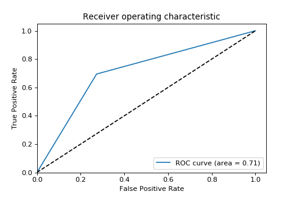

```python
# plotting roc curve with AUC
from sklearn.metrics import roc_curve, auc
false_positive_rate, true_positive_rate, thresholds = roc_curve(y_test, KNNNN)
roc_auc = auc(false_positive_rate, true_positive_rate)

# Plot of a ROC curve for a classification tree
%matplotlib notebook
plt.figure()
plt.plot(false_positive_rate, true_positive_rate, label='ROC curve (area = %0.2f)' % roc_auc)
plt.plot([0, 1], [0, 1], 'k--')
plt.xlim([0.0, 1.05])
plt.ylim([0.0, 1.05])
plt.xlabel('False Positive Rate')
plt.ylabel('True Positive Rate')
plt.title('Receiver operating characteristic')
plt.legend(loc="lower right")
plt.show()
```

# Random Forest

```python
from sklearn.ensemble import RandomForestClassifier
from sklearn.model_selection import StratifiedKFold
from sklearn.metrics import accuracy_score
i=1
kf = StratifiedKFold(n_splits=3,random_state=1,shuffle=True)
for train_index,test_index in kf.split(X,y):
    print('\n{} of kfold {}'.format(i,kf.n_splits))
    #xtr,xvl = X.loc[train_index],X.loc[test_index]
    #ytr,yvl = y[train_index],y[test_index]
    model = RandomForestClassifier(random_state=1, max_depth=10)
    model.fit(X_train_std, y_train)
    pred_test = model.predict(X_test_std)
    score = accuracy_score(y_test,pred_test)
    print ('accuracy_score',score)
    i+=1
```

```
1 of kfold 3
accuracy_score 0.7338775510204082

2 of kfold 3
accuracy_score 0.7338775510204082

3 of kfold 3
accuracy_score 0.7338775510204082
```

```python
RFF_PREDICTIONS = model.predict(X_test_std)
```

```python
accuracy = sklearn.metrics.accuracy_score(y_test, RFF_PREDICTIONS)
sensitivity = confusion[1][1]/float(confusion[1:].sum())
specificity = confusion[0][0]/float(confusion[:,0].sum())
print ("The accuracy is {0:.3f}".format(accuracy))
print ("The sensitivity is {0:.3f}".format(sensitivity))
print ("The specificity is {0:.3f}".format(specificity))
```

```
The accuracy is 0.734
The sensitivity is 0.621
The specificity is 0.684
```

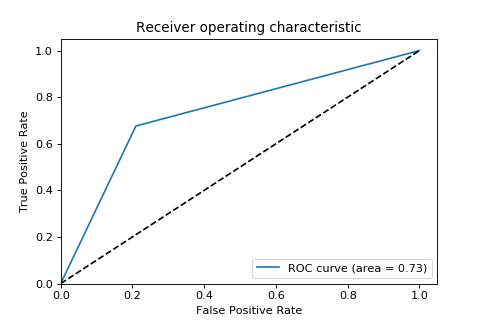

```python
# plotting roc curve with AUC
from sklearn.metrics import roc_curve, auc
false_positive_rate, true_positive_rate, thresholds = roc_curve(y_test,RFF_PREDICTIONS)
roc_auc = auc(false_positive_rate, true_positive_rate)

# Plot of a ROC curve for a classification tree
%matplotlib notebook
plt.figure()
plt.plot(false_positive_rate, true_positive_rate, label='ROC curve (area = %0.2f)' % roc_auc)
plt.plot([0, 1], [0, 1], 'k--')
plt.xlim([0.0, 1.05])
plt.ylim([0.0, 1.05])
plt.xlabel('False Positive Rate')
plt.ylabel('True Positive Rate')
plt.title('Receiver operating characteristic')
plt.legend(loc="lower right")
plt.show()
```

```python
randomforest1_predictions = model.predict(df1_testing)
RF_predictions = pd.DataFrame(randomforest1_predictions)
RF_predictions.shape
```

```
(21000, 1)
```

```python
submission_df = pd.concat([submission_df, RF_predictions], axis=1, sort=False)
submission_df.shape
```

```
(21000, 5)
```

```python
submission_df.to_csv('ons_4_assign3_da.csv', index=False)
```

```python
X_train.columns
```

```
Index(['Age', 'HinCM', 'Weight', 'High Blood Pressure', 'Low Blood Pressure',
       'Cholesterol', 'Glucose', 'Smoke', 'Alcohol', 'Exercise',
       'Gender_female', 'Gender_male'],
      dtype='object')
```

```python
aa = pd.DataFrame(X_train_std)
aa.head()

aa.columns = ['Age', 'HinCM', 'Weight', 'High Blood Pressure', 'Low Blood Pressure',
       'Cholesterol', 'Glucose', 'Smoke', 'Alcohol', 'Exercise',
       'Gender_female', 'Gender_male']
```

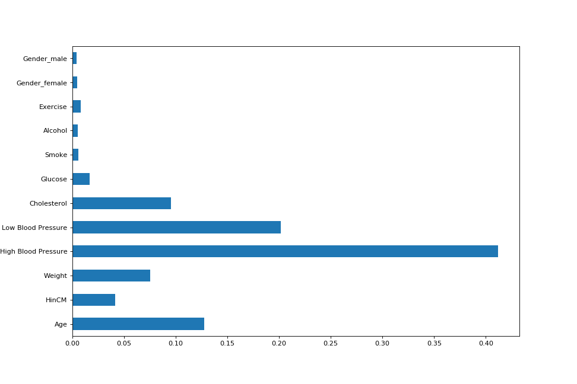

```python
#FEATURE IMPORTANCE
fig = plt.figure(figsize=(12,8))
importances=pd.Series(model.feature_importances_, index=aa.columns)
importances.plot(kind='barh')
plt.show()
```

# XGBOOST

```python
from xgboost import XGBClassifier
i=1
kf = StratifiedKFold(n_splits=3,random_state=1,shuffle=True)
for train_index,test_index in kf.split(X,y):
    print('\n{} of kfold {}'.format(i,kf.n_splits))
    #xtr,xvl = X.loc[train_index],X.loc[test_index]
    #ytr,yvl = y[train_index],y[test_index]
    model = XGBClassifier(n_estimators=50, max_depth=4)
    model.fit(X_train_std, y_train)
    pred_test = model.predict(X_test_std)
    score = accuracy_score(y_test,pred_test)
    print('accuracy_score',score)
    i+=1
```

```
1 of kfold 3
accuracy_score 0.7342176870748299

2 of kfold 3
accuracy_score 0.7342176870748299

3 of kfold 3
accuracy_score 0.7342176870748299
```

```python
XGBOOST_predictions = model.predict(df1_testing)
XG_predictions = pd.DataFrame(XGBOOST_predictions)
XG_predictions.shape
```

```
(21000, 1)
```

```python
submission_df = pd.concat([submission_df, XG_predictions], axis=1, sort=False)
submission_df.shape
```

```
(21000, 6)
```

```python
submission_df.to_csv('ons_4_assign3_da.csv', index=False)
```

```python
XG_PREDICTIONS = model.predict(X_test_std)
```

```python
accuracy = sklearn.metrics.accuracy_score(y_test, XG_PREDICTIONS)
sensitivity = confusion[1][1]/float(confusion[1:].sum())
specificity = confusion[0][0]/float(confusion[:,0].sum())
print ("The accuracy is {0:.3f}".format(accuracy))
print ("The sensitivity is {0:.3f}".format(sensitivity))
print ("The specificity is {0:.3f}".format(specificity))
```

```
The accuracy is 0.734
The sensitivity is 0.621
The specificity is 0.684
```

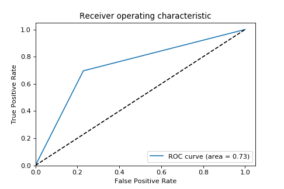

```python
# plotting roc curve with AUC
from sklearn.metrics import roc_curve, auc
false_positive_rate, true_positive_rate, thresholds = roc_curve(y_test,XG_PREDICTIONS)
roc_auc = auc(false_positive_rate, true_positive_rate)

# Plot of a ROC curve for a classification tree
%matplotlib notebook
plt.figure()
plt.plot(false_positive_rate, true_positive_rate, label='ROC curve (area = %0.2f)' % roc_auc)
plt.plot([0, 1], [0, 1], 'k--')
plt.xlim([0.0, 1.05])
plt.ylim([0.0, 1.05])
plt.xlabel('False Positive Rate')
plt.ylabel('True Positive Rate')
plt.title('Receiver operating characteristic')
plt.legend(loc="lower right")
plt.show()
```